# Heterogeneity of effects, Random Slopes

MLM Lab Workshop

Michael Hallquist

4Mar2021

# 1 Important messages from Bolger et al., 2019

One of the sacred cows of experimental psychology is that mean differences between levels of an experimentally manipulated factor provide evidence of the causal importance of that factor.

For example, if I am testing the effect of distraction on working memory performance, I might manipulate the loudness of background music during a computer-based digit span task in which each subject completes 12 trials. I might try three levels of music: none, quiet (50 dB), or loud (80 dB). Imagine that I run this experiment in 75 subjects, randomly assigning 25 to each music condition. Here are the condition means and SDs of number of digits recalled, averaging number of words per subject before computing the condition means.

| Condition | Mean | SD |
| --- | --- | --- |
| No music | 7.2 | 1.4 |
| Quiet | 6.8 | 1.5 |
| Loud | 5.5 | 2.5 |

In this case, I might run a one-way ANOVA and observe the following:

```r
digit_data <- mvrnorm(n=25, mu=c(7.2, 6.8, 5.5), Sigma=diag(c(1.4, 1.5, 2.5))^2, empirical=T) %>% as.data.frame() %>%
  setNames(c("none", "quiet", "loud")) %>%
  pivot_longer(cols = everything(), names_to = "condition", values_to = "digit_span") %>%
  mutate(id=1:n(), condition=ordered(condition, levels=c("none", "quiet", "loud")))

aobj <- afex::aov_ez(id="id", dv="digit_span", between = "condition", data=digit_data)
```

```
## Contrasts set to contr.sum for the following variables: condition
```

```r
summary(aobj)
```

|  | num Df | den Df | MSE | F | ges | Pr(>F) |
| --- | --- | --- | --- | --- | --- | --- |
| condition | 2 | 72 | 3.49 | 5.66 | 0.136 | 0.005 |

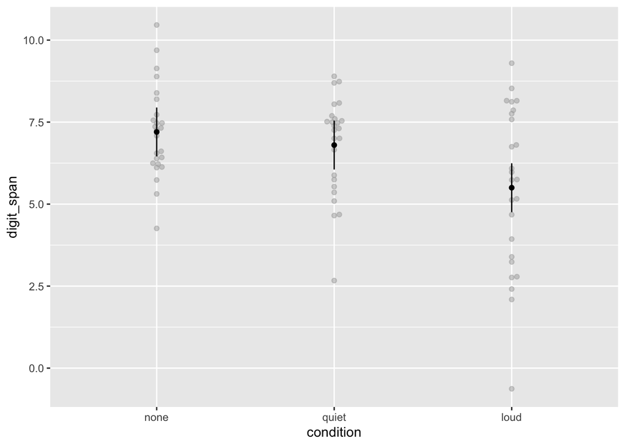

```r
afex::afex_plot(aobj, x="condition")
```

```r
m1 <- emmeans(aobj, ~condition)
pairs(m1)
```

```
##  contrast     estimate    SE df t.ratio p.value
##  none - quiet      0.4 0.528 72 0.760   0.7300
##  none - loud       1.7 0.528 72 3.220   0.0050
##  quiet - loud      1.3 0.528 72 2.460   0.0420
##
## P value adjustment: tukey method for comparing a family of 3 estimates
```

Looks like it’s time to write a paper!! I’m loving that omnibus *p*-value. The Tukey-adjusted pairwise tests also suggest that it’s really the loud music that is disruptive to digit span, while quiet music has a non-significant impact.

## 1.1 Under the hood of ANOVA: assuming causal homogeneity

Importantly, however, we have done some violence to the data in our effort to summarize effects in the sample. As noted above we, aggregate the 12 trials per subject to derive subject means for ANOVA, so we’ve already remove within-subject variability. Furthermore, our statistics assume that the causal effect of music on digit span is essentially *homogeneous* across people. That is, we are saying that there is no interesting variation in the mean difference between two conditions across people.

Bolger and colleagues note, however, that experimental manipulations may have *heterogeneous* effects on the outcome variable (here, digit span) across people. Imagine a person who is hearing-impaired — they are unlikely to suffer much performance penalty on the task as music volume is increased.

If we manipulate a factor between subjects, we cannot know whether individual differences in values within a given condition (to which people are randomly assigned) is due to measurement error or other noncausal factors. If we manipulate the factor within subjects, however, we can potentially tap into causal effect heterogeneity and, moreover, model both its magnitude and identify between-subjects predictors that account for this heterogeneity.

Multilevel models are ideally suited to model causal effect heterogeneity when we have repeated measures for each person (level 2 unit). The key asset of these models in this regard is that they can estimate person-specific associations between an experimental factor and the outcome through the incorporation of a random slope (variance component) for that factor.

**For discussion**: If I have a between-subjects factor (e.g., level of background music) but observe the dependent variable many times (e.g., digit span performance on 12 trials), can I estimate causal effect heterogeneity because I have repeated measures?

As Bolger and colleagues note, “Even if experimenters wish to focus solely on average causal effects, this approach [repeated-measures ANOVA] should ideally be justified by a mixed-model analysis showing that causal heterogeneity is minor and ignorable.” (p. 614).

## 1.2 Analyzing the same data within an MLM framework

```r
## scale data up to 12 trials per subject
f_var_alpha <- function(ICC, var_epsilon){
  var_alpha <- (ICC*var_epsilon)/(1-ICC)
  return(var_alpha)
}

#simulate data with approx. ICC of 0.3, but keep person and condition means the same as above
var_alpha <- f_var_alpha(ICC = 0.3, var_epsilon = 15)

df_multilevel <- bind_rows(lapply(1:nrow(digit_data), function(rr) {

  multi_trial <- mvrnorm(n=12, mu = digit_data$digit_span[rr],
                         Sigma = var_alpha, empirical=T) %>%
    as.data.frame() %>%
    setNames("digit_span") %>%
    mutate(condition=digit_data$condition[rr], id=digit_data$id[rr])

  return(multi_trial)
})) %>% mutate(id=factor(id), condition=as.factor(as.character(condition))) #remove ordered

mlm_obj <- lmer(digit_span ~ condition + (1|id), data=df_multilevel)
performance::icc(mlm_obj)
```

```
## # Intraclass Correlation Coefficient
##
##      Adjusted ICC: 0.315
##   Conditional ICC: 0.298
```

```r
summary(mlm_obj)
```

```
## Linear mixed model fit by REML. t-tests use Satterthwaite's method ['lmerModLmerTest']
## Formula: digit_span ~ condition + (1 | id)
##    Data: df_multilevel
##
## REML criterion at convergence: 4367
##
## Scaled residuals:
##     Min      1Q  Median      3Q     Max
## -2.6086 -0.6928 -0.0097  0.7114  2.4803
##
## Random effects:
##  Groups   Name        Variance Std.Dev.
##  id       (Intercept) 2.95     1.72
##  Residual             6.43     2.54
## Number of obs: 900, groups:  id, 75
##
## Fixed effects:
##                Estimate Std. Error     df t value Pr(>|t|)
## (Intercept)       5.500      0.373 72.000   14.73   <2e-16 ***
## conditionnone     1.700      0.528 72.000    3.22   0.0019 **
## conditionquiet    1.300      0.528 72.000    2.46   0.0162 *
## ---
## Signif. codes:  0 '***' 0.001 '**' 0.01 '*' 0.05 '.' 0.1 ' ' 1
##
## Correlation of Fixed Effects:
##             (Intr) cndtnn
## conditionnn -0.707
## conditionqt -0.707  0.500
```

We can try to hack the condition into the model as a random slope, but we should be worried. What is wrong with this?

```r
mlm_obj <- lmer(digit_span ~ condition + (1 + condition | id), data=df_multilevel)
summary(mlm_obj)
```

```
## Linear mixed model fit by REML. t-tests use Satterthwaite's method ['lmerModLmerTest']
## Formula: digit_span ~ condition + (1 + condition | id)
##    Data: df_multilevel
##
## REML criterion at convergence: 4356
##
## Scaled residuals:
##     Min      1Q  Median      3Q     Max
## -2.6824 -0.6909 -0.0247  0.7144  2.5501
##
## Random effects:
##  Groups   Name           Variance Std.Dev. Corr
##  id       (Intercept)     5.71    2.39
##           conditionnone   8.51    2.92     -0.92
##           conditionquiet 10.73    3.28     -0.94  0.89
##  Residual                 6.43    2.54
## Number of obs: 900, groups:  id, 75
##
## Fixed effects:
##                Estimate Std. Error     df t value Pr(>|t|)
## (Intercept)       5.500      0.500 23.999   11.00  7.4e-11 ***
## conditionnone     1.700      0.573 37.703    2.97   0.0052 **
## conditionquiet    1.300      0.583 39.296    2.23   0.0316 *
## ---
## Signif. codes:  0 '***' 0.001 '**' 0.01 '*' 0.05 '.' 0.1 ' ' 1
##
## Correlation of Fixed Effects:
##             (Intr) cndtnn
## conditionnn -0.873
## conditionqt -0.857  0.748
## optimizer (nloptwrap) convergence code: 0 (OK)
## unable to evaluate scaled gradient
## Model failed to converge: degenerate  Hessian with 2 negative eigenvalues
```

## 1.3 Objectives of Bolger and colleagues

1. “To convince experimentalists in psychology to change their metatheory of causal processes from a one-size-fits-all view to one that allows for subject-level heterogeneity.”
2. “To provide the field with an accessible guide on how to estimate, display, and draw theoretical implications from causal effect heterogeneity.”
3. “To show that attention to causal effect heterogeneity will lead to better research practice.”

The TL;DR version of these objectives in the context of MLMs is: “Include experimental factors as random slopes in a multilevel model framework and examine whether there is significant between-person variation in the effect of these factors on the dependent variable.”

## 1.4 Trait valence effects (Experiment 1)

```r
rndt <- read.csv("heterogeneity_dataset1_traitvalence.csv") %>%
  filter(response.keys=="up") %>%  # subset to only select traits endorsed as self-relevant
  mutate(
    rt.z = as.vector(scale(rt)),
    valence_fac = factor(valenceE, levels=c(-0.5, 0.5), labels=c("negative", "positive"))
  ) %>%
  filter(rt.z < 3) %>% #within +3 SD of the mean RT
  filter(!id %in% c(250, 257, 272)) # drop three participants who did not select any negative words


# Compute the number of positive and negative words endorsed, plus ratio of positive to negative
# .c: centering proportion on mean, which is 62% of words endorsed as positive
rndt <- rndt %>%
  mutate(posval = ifelse(valenceE == .5, 1, 0),
         numpos = ave(posval, id, FUN = sum.na),
         negval = ifelse(valenceE == -.5, 1, 0),
         numneg = ave(negval, id, FUN = sum.na),
         valenceprop = numpos/(numpos + numneg),
         valenceprop.c = valenceprop - mean(valenceprop)
  )
```

Here, I present the data from Experiment 1 in Bolger and colleagues (2019), which I downloaded here: https://github.com/kzee/heterogeneityproject. Description, “Participants were presented with positively and negatively valenced trait words and asked to indicate whether each of the words was self-descriptive. Response time for each word was measured. A straightforward prediction is that participants will be faster to endorse positive self-descriptions, given that people are motivated to maintain a positive self-view.”

Following the paper, we will analyze only traits endorsed as self-relevant. We also drop RTs > 3 SDs above the sample average and drop three participants who did not endorse any negative words.

Note that as with our flanker data, we see positive skewness of RTs and a log transformation cleans them up.

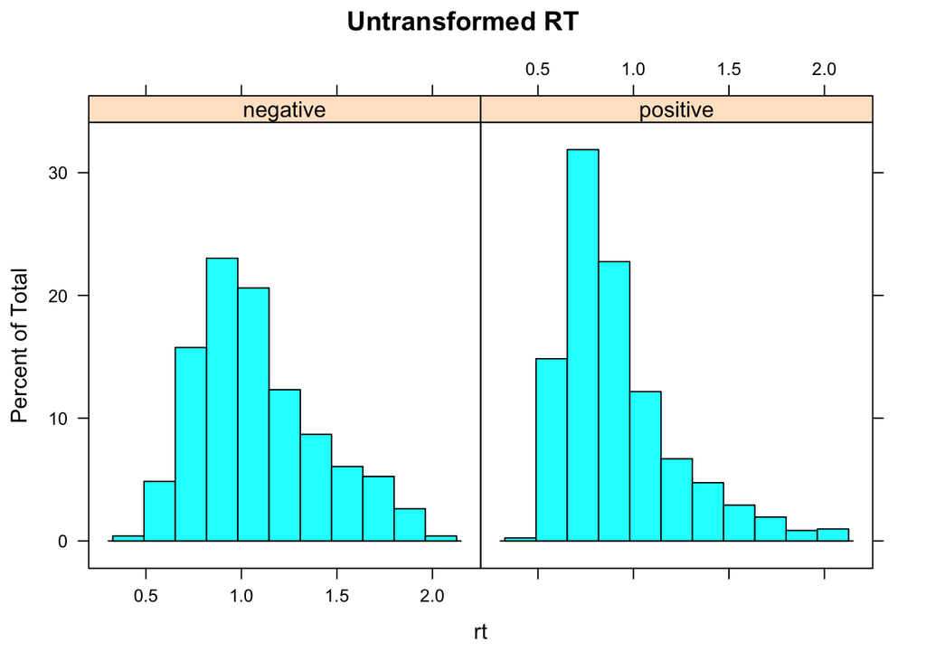

```r
lattice::histogram(~rt | valence_fac, rndt, main="Untransformed RT")
```

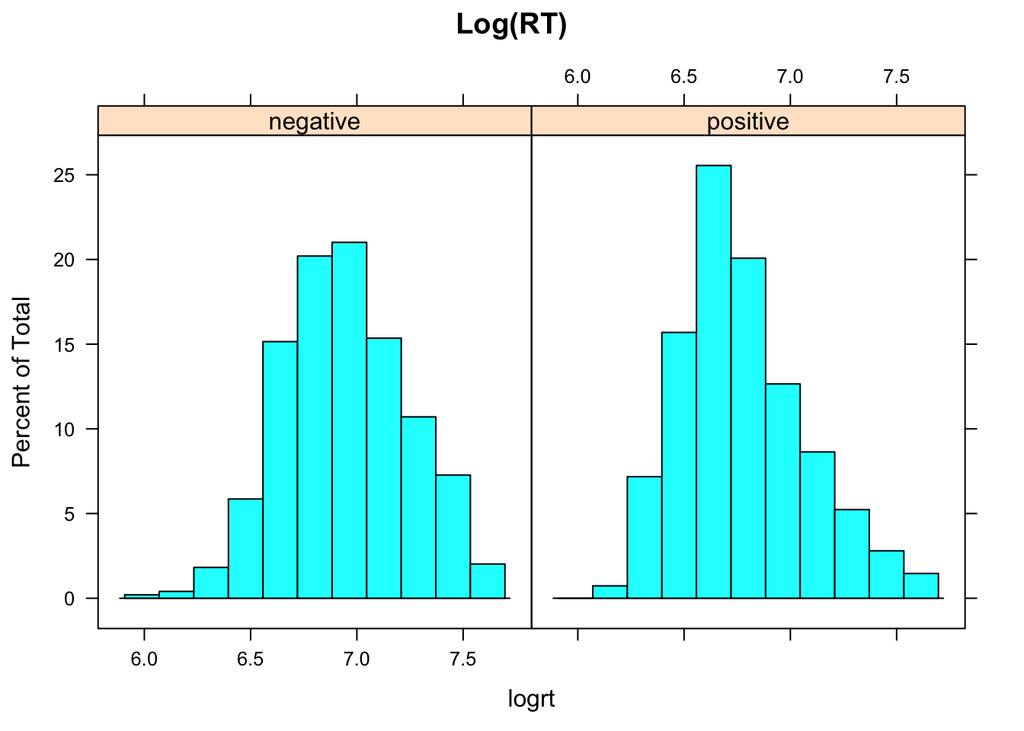

```r
lattice::histogram(~logrt | valence_fac, rndt, main="Log(RT)")
```

First, let’s analyze the data under the assumption that participants can differ in mean RT, but that the effect of valence (positive, negative) is the same across people. In MLM terms, this is a random intercept (only) model:

$$\log(\textrm{RT}_{ij}) \sim \mathcal{N}(\mu_j + \beta_1 \textrm{valence}_{ij}, \sigma_\varepsilon) \\
\mu_j \sim \mathcal{N}(\gamma_{00}, \tau_{00})$$

Here, we have a *distribution* of intercepts with variance $\tau_{00}$ centered on the sample-average intercept $\gamma_{00}$. But the coefficient for the effect of valence on RT is unitary – there is no between-subjects variation. In MLM speak, valence is a fixed effect in the model, but not random.

```r
# lmer logrt - f(valence) with random intercepts only
valrt_intonly <- lmer(logrt ~ valence_fac + (1 | id),  data=rndt)
summary(valrt_intonly)
```

```
## Linear mixed model fit by REML. t-tests use Satterthwaite's method ['lmerModLmerTest']
## Formula: logrt ~ valence_fac + (1 | id)
##    Data: rndt
##
## REML criterion at convergence: 223
##
## Scaled residuals:
##    Min     1Q Median     3Q    Max
## -3.846 -0.690 -0.118  0.576  3.266
##
## Random effects:
##  Groups   Name        Variance Std.Dev.
##  id       (Intercept) 0.0259   0.161
##  Residual             0.0620   0.249
## Number of obs: 1317, groups:  id, 59
##
## Fixed effects:
##                     Estimate Std. Error       df t value Pr(>|t|)
## (Intercept)            6.934      0.024   79.823   289.0   <2e-16 ***
## valence_facpositive   -0.154      0.015 1285.126   -10.3   <2e-16 ***
## ---
## Signif. codes:  0 '***' 0.001 '**' 0.01 '*' 0.05 '.' 0.1 ' ' 1
##
## Correlation of Fixed Effects:
##             (Intr)
## vlnc_fcpstv -0.392
```

Now let’s allow for heterogeneity in the effect of valence on RT. To do this, we add a random slope (variance component) of valence.

$$\log(\textrm{RT}_{ij}) \sim \mathcal{N}(\mu_j + \beta_{1j} \textrm{valence}_{ij}, \sigma_\varepsilon) \\
\mu_j \sim \mathcal{N}(\gamma_{00}, \tau_{00}) \\
\beta_{1j} \sim \mathcal{N}(\gamma_{10}, \tau_{11})$$

The major innovation here is that the slope coefficient $\beta_{1j}$ is now allowed to vary from one subject to the next, with between-subjects heterogeneity (variance) being captured by $\tau_{11}$. As before, we retain the sample-average slope in the model as a fixed effect, captured by $\gamma_{10}$.

```r
# with random alopes (used in paper)
valrt_intslope <- lmer(logrt ~ valence_fac + (1 + valence_fac | id),  data=rndt)
summary(valrt_intslope)
```

```
## Linear mixed model fit by REML. t-tests use Satterthwaite's method ['lmerModLmerTest']
## Formula: logrt ~ valence_fac + (1 + valence_fac | id)
##    Data: rndt
##
## REML criterion at convergence: 202
##
## Scaled residuals:
##    Min     1Q Median     3Q    Max
## -3.800 -0.669 -0.127  0.542  3.365
##
## Random effects:
##  Groups   Name                Variance Std.Dev. Corr
##  id       (Intercept)         0.0329   0.181
##           valence_facpositive 0.0156   0.125    -0.43
##  Residual                     0.0587   0.242
## Number of obs: 1317, groups:  id, 59
##
## Fixed effects:
##                     Estimate Std. Error      df t value Pr(>|t|)
## (Intercept)           6.9471     0.0265 54.0475  261.85  < 2e-16 ***
## valence_facpositive  -0.1616     0.0222 51.2479   -7.29  1.9e-09 ***
## ---
## Signif. codes:  0 '***' 0.001 '**' 0.01 '*' 0.05 '.' 0.1 ' ' 1
##
## Correlation of Fixed Effects:
##             (Intr)
## vlnc_fcpstv -0.532
```

```r
# convert ranefs to a dataframe
valrt_intslope_tidy <- tidy(valrt_intslope)
```

We’ll cover this in more detail later, but at a high level, we should wonder: does the addition a random slope to the model substantially improve fit? If it does not, this suggests there is not meaningful between-person variation in the effect of valence on RT. If it does improve fit, we should probably retain the variance component for valence and perhaps also look for variables that explain between-person variation in this slope.

We will use a likelihood ratio test (LRT) to compare the two models in terms of their relative fit. A significant *p*-value indicates evidence of improved fit in one model over the other.

```r
anova(valrt_intonly, valrt_intslope) #Compares heterogeneity with no-heterogeneity model using LR Chi-square test
```

```
## refitting model(s) with ML (instead of REML)
```

|  | npar | AIC | BIC | logLik | deviance | Chisq | Df | Pr(>Chisq) |
| --- | --- | --- | --- | --- | --- | --- | --- | --- |
| valrt_intonly | 4 | 218 | 239 | -105.2 | 210 | NA | NA | NA |
| valrt_intslope | 6 | 203 | 234 | -95.3 | 191 | 19.8 | 2 | 0 |

This LRT suggests that there is substantial between-person variation in the effect of valence on RT.

### 1.4.1 When should we be concerned about heterogeneity of causal effects?

“We suggest that as a rule of thumb, causal effect heterogeneity is noteworthy if its SD is 0.25 or greater of the average (fixed) effect.”

## 1.5 Measurement error and shrinkage

“The mean difference between the subject’s responses across conditions is, in itself, an unbiased estimate of the subject’s causal effect. Its true value is uncertain to some extent, however, because we used only a limited number of trials within each condition. That uncertainty is indexed by the standard error of the subject’s mean difference, and one can think of it as a form of measurement error.”

“Now consider viewing the effect for a sample of subjects, each of whose experimental effect is uncertain. Just as one would see with a set of error-prone measurements, the observed variation will be the sum of the true variation and the error variation, and will always show an upward bias. In our example, the subject-by- subject valence effect heterogeneity must be adjusted downward (‘shrunken’) in order for it to be a valid estimate of true population heterogeneity. Mixed models provide a way of accomplishing this… The more uncertain a subject’s raw mean difference, the more it is shrunken toward the estimated population mean.”

Figure 3 from the paper:

```r
cfs2 <- ranef(valrt_intslope)$id
cfs2$id <- row.names(cfs2)
colnames(cfs2) <- c("ebintercept", "ebslope", "id")


# adding in fixed effects
cfs2$intercept <- summary(valrt_intslope)$coeff["(Intercept)", "Estimate"] + cfs2$ebintercept
cfs2$slope <- summary(valrt_intslope)$coeff["valence_facpositive", "Estimate"] + cfs2$ebslope


rndtznum <- dplyr::select(rndt, id, numneg)
#rndtznum[order(rndtznum$numneg),]
# need to omit 306 bc this participant only chose 1 neg trait

ids <- unique(subset(rndt, id != 306)$id)
diff <- data.frame(sub = ids, diff = NA, lower = NA, upper = NA)
for(i in ids){
  data_i <- subset(rndt, rndt$id == i)
  rts <- split(data_i, data_i$valence_fac)
  t <- t.test(rts$negative[, "logrt"], rts$positive[, "logrt"])
  diff[i, 2:4] <- c((t$estimat[2]-t$estimat[1]), t$conf.int[2:1])
}
diff_i <- diff[order(diff$diff),]
diff_i$id <- as.numeric(row.names(diff_i))
diff_i$lower <- -1*diff_i$lower
diff_i$upper <- -1*diff_i$upper
diff_i <- subset(diff_i, is.na(diff)==F)

## Merge raw estimates with model estimates of valence effect

valranefs <- dplyr::select(cfs2, id, slope)
valestimates <- merge(diff_i, valranefs, by = 'id')
valestimates2 <- valestimates[order(valestimates$diff),]
head(valestimates2)
```

|  | id | sub | diff | lower | upper | slope |
| --- | --- | --- | --- | --- | --- | --- |
| 43 | 263 | NA | -0.621 | -0.772 | -0.470 | -0.289 |
| 7 | 208 | NA | -0.569 | -0.782 | -0.357 | -0.387 |
| 56 | 303 | NA | -0.546 | -1.078 | -0.014 | -0.282 |
| 40 | 255 | NA | -0.488 | -0.843 | -0.133 | -0.323 |
| 14 | 222 | NA | -0.456 | -0.676 | -0.236 | -0.340 |
| 47 | 267 | NA | -0.433 | -0.751 | -0.115 | -0.292 |

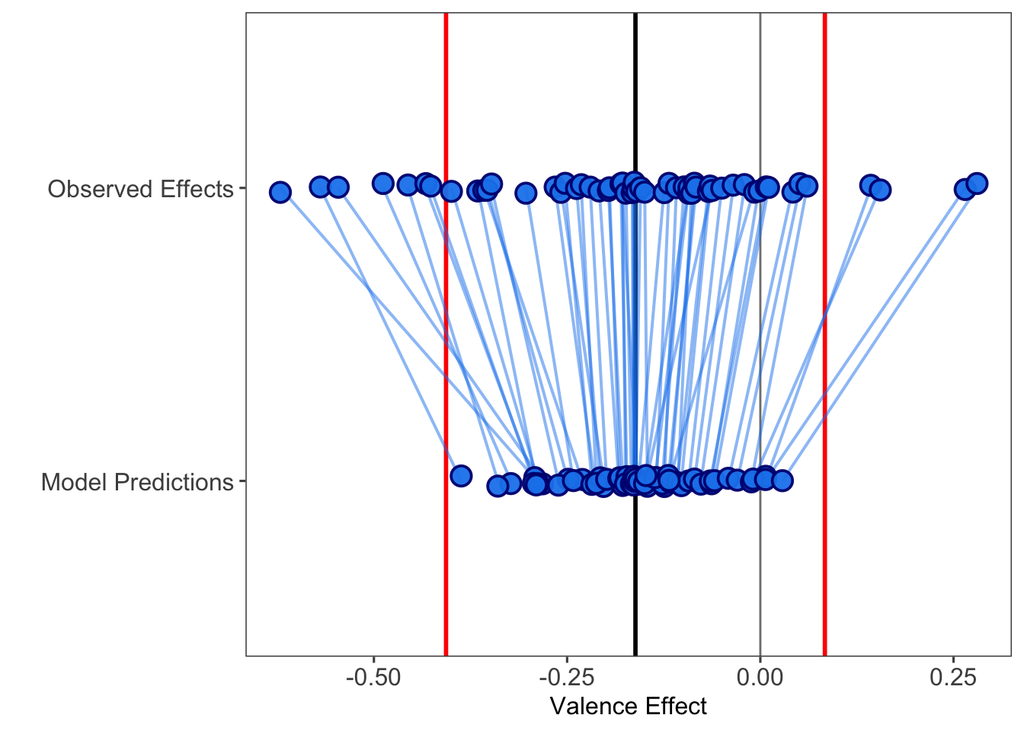

```r
valestimates2$idorder <- 1:58

valestimates_rawdiff <- dplyr::select(valestimates2, id, diff)
colnames(valestimates_rawdiff) <- c('id', 'diff_rt')
valestimates_rawdiff$type <- "Observed Effects"

valestimates_preddiff <- dplyr::select(valestimates2, id, slope)
colnames(valestimates_preddiff) <- c('id', 'diff_rt')
valestimates_preddiff$type <- "Model Predictions"

valestimates3 <- rbind(valestimates_rawdiff, valestimates_preddiff)


plotvalest2 <- ggplot(valestimates3, aes(type, diff_rt)) +
  geom_hline(yintercept = summary(valrt_intslope)$coeff["valence_facpositive", "Estimate"] , size = 1, color = "black") +
  geom_hline(yintercept = 0, size = .5, color = "gray50", linetype = "solid") +
  geom_hline(yintercept = fixef(valrt_intslope)[2] + -1.96*subset(valrt_intslope_tidy, term == "sd__valence_facpositive")$estimate, size = 1, color = "red") +
  geom_hline(yintercept = fixef(valrt_intslope)[2] + 1.96*subset(valrt_intslope_tidy, term == "sd__valence_facpositive")$estimate, size = 1, color = "red") +
  geom_line(aes(group = id), color = "dodgerblue2", size = .7, alpha = .5) +
  geom_jitter(width = .02, height = 0, size = 4,
              shape = 21, colour = "navyblue", fill = "dodgerblue2", alpha = .95, stroke = 1)+
  xlab(" ") + ylab("Valence Effect") +
  theme_few() +
  theme(axis.text.x=element_text(size=12),
        axis.text.y=element_text(size=12),
        axis.title.y=element_text(size=12)) +
  coord_flip()
plotvalest2
```

```r
#ggsave(plotvalest2, file = "Fig3_plotvalest2.pdf", height = 4, width = 8)
```

## 1.6 Between-subjects predictors of variation in effect of valence

“What can explain why some participants respond faster to positive traits while others show no difference or even the reverse pattern?”

This is a question of what variables account for the random slope variance ($\tau_{11}$) for valence.

MNH: Fig 10 is essentially added variable plot for RE of valence MNH: Fig 9 shows how explaining variance in a random effect leads to less residual heterogeneity.

```r
# creating centered promotion

promdf <- subset(rndt, !duplicated(id))
promdf2 <- dplyr::select(promdf, id, prom.v)
promdf2$prom.c <- scale(promdf2$prom.v, center = T, scale = F)

rndt <- merge(rndt, promdf2, by = "id")
sd(rndt$prom.c)
```

```
## [1] 0.47
```

## 1.7 Valence RT effect moderated by promotion

```r
modindiv1 <- lmer(logrt ~ valenceE*prom.c + (1 + valenceE| id),  data=rndt)
summary(modindiv1)
```

```
## Linear mixed model fit by REML. t-tests use Satterthwaite's method ['lmerModLmerTest']
## Formula: logrt ~ valenceE * prom.c + (1 + valenceE | id)
##    Data: rndt
##
## REML criterion at convergence: 196
##
## Scaled residuals:
##    Min     1Q Median     3Q    Max
## -3.755 -0.664 -0.119  0.553  3.323
##
## Random effects:
##  Groups   Name        Variance Std.Dev. Corr
##  id       (Intercept) 0.0255   0.160
##           valenceE    0.0133   0.116    -0.27
##  Residual             0.0586   0.242
## Number of obs: 1317, groups:  id, 59
##
## Fixed effects:
##                 Estimate Std. Error      df t value Pr(>|t|)
## (Intercept)       6.8694     0.0221 56.1935  310.76  < 2e-16 ***
## valenceE         -0.1616     0.0213 52.1337   -7.58  5.7e-10 ***
## prom.c           -0.1003     0.0452 56.8298   -2.22   0.0304 *
## valenceE:prom.c  -0.1294     0.0448 59.7857   -2.89   0.0053 **
## ---
## Signif. codes:  0 '***' 0.001 '**' 0.01 '*' 0.05 '.' 0.1 ' ' 1
##
## Correlation of Fixed Effects:
##             (Intr) valncE prom.c
## valenceE    -0.253
## prom.c       0.011 -0.061
## vlncE:prm.c -0.064  0.048 -0.198
```

```r
#confint(modindiv1)
```

## 1.8 Compute Conditional Variance

```r
##### Compute Conditional Variance ######

#Get interaction coefficient
valXprom.coeff <- fixef(modindiv1)[4]

#Get residual variance of valence random effect in model with promotion
residvalvar <- VarCorr(modindiv1, comp="Variance")$id["valenceE", "valenceE"]

#Calculate the implied total valence random effect variance
#imptotalvalvar <- sd(subset(rndt, trial==1)$prom.c)^2*valXprom.coeff^2 + valvariance # should valvariance be residvalvar?
imptotalvalvar <- valXprom.coeff^2*sd(promdf2$prom.c)^2 + residvalvar # should valvariance be residvalvar? # ^updated 181022 with better prom value
```

Variance Explained by Valence x Promotion interaction - 23% of variance explained by interaction effect

```r
## Variance Explained by Valence x Promotion interaction
1-(residvalvar/imptotalvalvar)
```

```
## valenceE:prom.c
##           0.235
```

```r
# 23% of variance explained by interaction effect
```

## 1.9 Valence X Promotion Figures

Save random effects and compute quantiles

```r
promotionranef <- ranef(modindiv1)$id
colnames(promotionranef) <- c("intercept_prom", "slope_prom")

promotionranef$id <- as.numeric(row.names(promotionranef))

#Create dataset with one line per person with prom.c score
promotionranef <- merge(promotionranef, promdf2, by = 'id')
#Add prom.c scores to file with valence slopes for prom.c model
#promotionranef$prom.c

# Person-specific implied total valence effects for model controlling for promotion focus
ranef.prom.pred.tot <- fixef(modindiv1)[2] +
                   fixef(modindiv1)[4]*promotionranef$prom.c +
                  ranef(modindiv1)$id[,2]

#Quantile for same
ranef.prom.pred.tot.quant <- as.vector(quantile(ranef.prom.pred.tot, probs=c(.025, .975)))
ranef.prom.pred.tot.pop1 <- c(mean(ranef.prom.pred.tot) + -1.96*sd(ranef.prom.pred.tot),
                             mean(ranef.prom.pred.tot) + 1.96*sd(ranef.prom.pred.tot))
ranef.prom.pred.tot.pop <- c(mean(ranef.prom.pred.tot) + -1.96*sqrt(imptotalvalvar),
                             mean(ranef.prom.pred.tot) + 1.96*sqrt(imptotalvalvar))



# population limits for model with promotion
modindiv1_tidy <- tidy(modindiv1)
ranef.valrt.prom.pop <- c(fixef(modindiv1)[2] + -1.96*subset(valrt_intslope_tidy, term == "sd__valence_facpositive")$estimate, fixef(modindiv1)[2] + 1.96*subset(valrt_intslope_tidy, term == "sd__valence_facpositive")$estimate)

# Person-specific residual valence effects for model controlling for promotion focus
ranef.prom.pred.resid <- fixef(modindiv1)[2] + ranef(modindiv1)$id[,2]

#Quantile for same
ranef.prom.pred.resid.quant <- as.vector(quantile(ranef.prom.pred.resid, probs=c(.025, .975)))
```

## 1.10 Strip Plots showing Effect of Promotion on Heterogeneity

Part 1

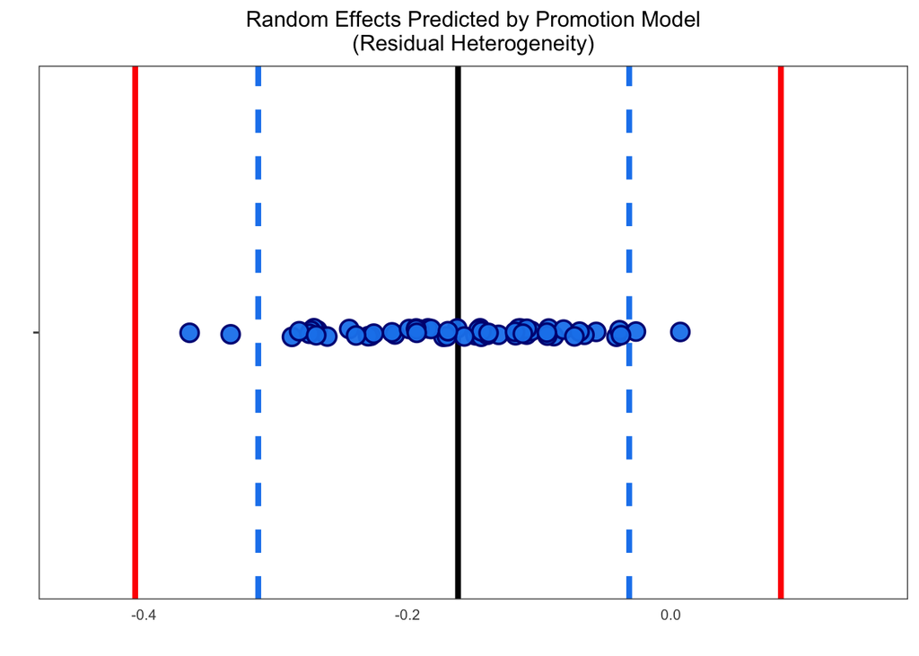

```r
### ggplot strip plot

promotionranef_noprom <- data.frame(id = row.names(ranef(modindiv1)$id), rt = (ranef.prom.pred.tot))
promotionranef_noprom$type <- "Predictions Removing Promotion Focus"


promotionranef_prom <- data.frame(id = row.names(ranef(modindiv1)$id), rt = (fixef(modindiv1)[2] + ranef(modindiv1)$id[,2]))
promotionranef_prom$type <- "Predictions with Promotion Focus"


promotion_stripplot <- ggplot(promotionranef_prom, aes(x=type, y=rt)) +
  theme(legend.position="none") +
  xlab(" ") + ylab(" ") + ggtitle("Random Effects Predicted by Promotion Model\n(Residual Heterogeneity)")+
  ylim(-.45, .15) +
  geom_hline(yintercept = ranef.prom.pred.resid.quant[1], size = 1.5, color = "dodgerblue2", linetype="dashed") +
  geom_hline(yintercept = ranef.prom.pred.resid.quant[2], size = 1.5, color = "dodgerblue2", linetype="dashed") +
    geom_hline(yintercept = ranef.valrt.prom.pop[1], size = 1.5, color = "red", linetype="solid") +
  geom_hline(yintercept = ranef.valrt.prom.pop[2], size = 1.5, color = "red", linetype="solid") +

  geom_hline(yintercept = fixef(modindiv1)[2], size = 1.5, color = "black", linetype="solid") +
    geom_jitter(width = 0.01, height = 0, size = 4,
              shape = 21, colour = "navyblue", fill = "dodgerblue2", alpha = .95, stroke = 1) +
  theme_few() +
  theme(text = element_text(size=10))  +
  theme(axis.ticks.x = element_blank(), axis.text.y = element_blank()) + coord_flip() +
    theme(plot.title = element_text(hjust = 0.5))
promotion_stripplot
```

Part 2

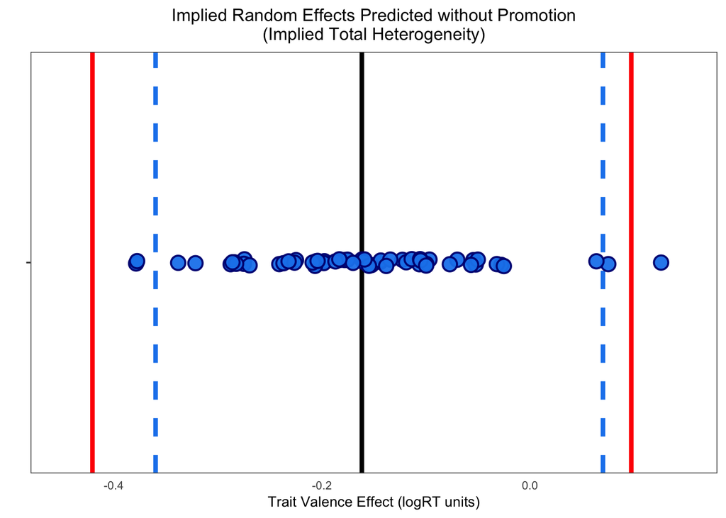

```r
nopromotion_stripplot <- ggplot(promotionranef_noprom, aes(x=type, y=rt)) +
  theme(legend.position="none") +
  xlab(" ") + ylab("Trait Valence Effect (logRT units)") +
  ggtitle("Implied Random Effects Predicted without Promotion\n(Implied Total Heterogeneity)")+
  ylim(-.45, .15) +
  geom_hline(yintercept = ranef.prom.pred.tot.quant[1], size = 1.5, color = "dodgerblue2", linetype="dashed") +
  geom_hline(yintercept = ranef.prom.pred.tot.quant[2], size = 1.5, color = "dodgerblue2", linetype="dashed") +

    geom_hline(yintercept = ranef.prom.pred.tot.pop[1], size = 1.5, color = "red", linetype="solid") +
  geom_hline(yintercept = ranef.prom.pred.tot.pop[2], size = 1.5, color = "red", linetype="solid") +

  geom_hline(yintercept = mean(ranef.prom.pred.tot), size = 1.5, color = "black", linetype="solid") +
    geom_jitter(width = 0.01, height = 0, size = 4,
              shape = 21, colour = "navyblue", fill = "dodgerblue2", alpha = .95, stroke = 1) +
  theme_few() +
  theme(text = element_text(size=10))  +
  theme(axis.ticks.x = element_blank(), axis.text.y = element_blank()) + coord_flip() +
    theme(plot.title = element_text(hjust = 0.5))
nopromotion_stripplot
```

```r
promotion_stripplots <- plot_grid(promotion_stripplot, nopromotion_stripplot, nrow = 2)
#ggsave(promotion_stripplots, file = "Fig9_promotion_stripplots.pdf", width = 8, height = 4)
```

# 2 Going further with random slopes

In my experience, people sometimes make the distinction of ‘random intercept’ versus ‘random slope’ models. Indeed, as we have seen, these models do differ in terms of allowing for heterogeneity in the per-cluster (per-person) average/intercept versus allowing for between-cluster heterogeneity in the association of a predictor with the outcome.

Importantly, however, there is not a single ‘random slope’ model. Rather, the effect of any L1 predictor may differ from one L2 unit to the next. Or in the case of experimental data where we have many trials per subject, we can imagine that any within-subjects predictor – either an experimental factor like incongruent/congruent condition in the flanker, or a continuous covariate like instantaneous heart rate – may have heterogeneous effects on the outcome across people.

As we scale up the number of random slopes in a model, estimation becomes much more difficult and we may see increasing evidence of model nonconvergence. We’ll talk about how to address this when we come to model selection.

## 2.1 For next time: R-side versus G-side random effects

## 2.2 For next time: correlated versus uncorrelated random effects